# Linear Regression Overview

Sanjeev Kumar

September 14, 2021

> You would want to keep a local copy of the `RMD` file and edit the file for the class exercise today. Submit an edited copy of the file as your class exercise submission.

Important Note: We will be doing class exercise today in a team of two students each. Figure out who you are working with. Move around if you need to.

# 1 Work Flow

- Step 0: Preparation
- Step 1: Running Linear Regression and Evaluating the Results
- Step 2: Making Predictions
- Step 3: Evaluating the Model Performance
- Step 4: Iterate to Find Best Model

# 2 Step 0: Preparation

Ensure that the data file is in the same directory as this .RMD file. Make that directory the working directory. `Session > Set Working Directory > To Source File Location`

## 2.1 Read and Explore Data

```r
# Reading the data file
Advertising <- read.csv("Advertising2.csv")
str(Advertising)
```

```
## 'data.frame':    200 obs. of  5 variables:
##  $ TV       : num  230.1 44.5 17.2 151.5 180.8 ...
##  $ Radio    : num  37.8 39.3 45.9 41.3 10.8 48.9 32.8 19.6 2.1 2.6 ...
##  $ Newspaper: num  69.2 45.1 69.3 58.5 58.4 75 23.5 11.6 1 21.2 ...
##  $ Instagram: chr  "Yes" "No" "No" "No" ...
##  $ Sales    : num  22.1 10.4 9.3 18.5 12.9 7.2 11.8 13.2 4.8 10.6 ...
```

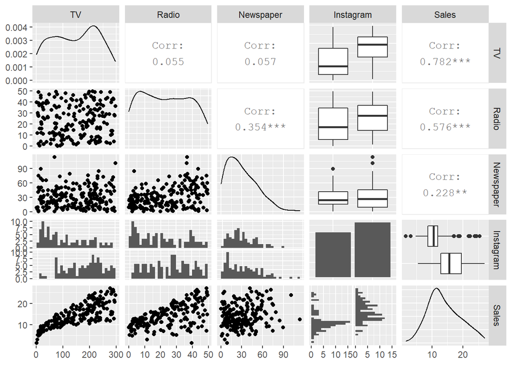

```r
# Explore the data
if(!"GGally" %in% installed.packages()){install.packages("GGally")}
library(GGally)
ggpairs(Advertising)
```

## 2.2 Data Cleaning

```r
# Start without Instagram (Factor) variable.
# All x's are numeric variables

Ad_small <- Advertising[,-4] #Without instagram
```

## 2.3 Split Data into Training set and Validation set

```r
#70-30 split
set.seed(567) #All your partioins for this class use this seed.
nrow(Ad_small)
```

```
## [1] 200
```

```r
train_set <- sample(1:nrow(Ad_small), 0.7*nrow(Ad_small))

#Training set
tr <- Ad_small[train_set, ]
x_tr <- Ad_small[train_set,-4] #x only
y_tr <- Ad_small[train_set,4] # y onle

#Validation set
val <- Ad_small[-train_set, ]
x_val <- Ad_small[-train_set,-4]  #x only
y_val <- Ad_small[-train_set,4]   #y only
```

# 3 Step 1: Running Linear Regression

```r
# Simple linear regression: Sales = b0 + b1*TV

m1 <- lm(Sales ~ TV, data =tr) #lm: linear model

# Regression output
summary(m1)
```

```
##
## Call:
## lm(formula = Sales ~ TV, data = tr)
##
## Residuals:
##     Min      1Q  Median      3Q     Max
## -8.7296 -1.5693 -0.1583  1.9430  6.8882
##
## Coefficients:
##             Estimate Std. Error t value Pr(>|t|)
## (Intercept) 7.307124   0.581440   12.57   <2e-16 ***
## TV          0.047786   0.003317   14.40   <2e-16 ***
## ---
## Signif. codes:  0 '***' 0.001 '**' 0.01 '*' 0.05 '.' 0.1 ' ' 1
##
## Residual standard error: 3.248 on 138 degrees of freedom
## Multiple R-squared:  0.6006, Adjusted R-squared:  0.5977
## F-statistic: 207.5 on 1 and 138 DF,  p-value: < 2.2e-16
```

```r
# Other regression outputs
ls(m1)
```

```
##  [1] "assign"        "call"          "coefficients"  "df.residual"
##  [5] "effects"       "fitted.values" "model"         "qr"
##  [9] "rank"          "residuals"     "terms"         "xlevels"
```

```r
m1$coefficients
```

```
## (Intercept)          TV
##  7.30712380  0.04778625
```

```r
m1$fitted.values #est. y-values for the training set.
```

```
##       141        28        69        46       106        95        21        76
## 10.814635 18.780603 18.651580 15.674497 13.896848 12.439367 17.743641  8.114711
##        20        54        82        47        29        62       182       185
## 14.346039 16.032894 18.766267 11.593551 19.196344 19.793672 17.748420 19.435275
##       166       135       101        16       153       170        15        74
## 18.513000  9.070437 17.934786 16.644558 16.749687 20.892756 17.060298 13.490665
##        56       193        58        55         2        87        90        36
## 16.811810  8.129047 13.815611 19.860572  9.433612 10.953215 12.554054 21.198588
##       110        71        84        31       118       132       145       190
## 19.511733 16.821367 10.575704 21.303717 10.957994 19.980038 11.904161  8.200727
##       164        13         9       160        41       129        27       125
## 15.120176  8.444437  7.718086 13.600573 16.983840 17.834435 14.135779 18.274069
##       140       111        80        81       136       155       102       138
## 16.142802 18.097260 12.850329 10.957994  9.615200 16.281382 21.470969 20.386221
##        38        78       146       165       151        72       176       124
## 10.876757 13.065367 14.011535 12.907673 20.720725 12.554054 20.539137 13.189612
##       180       171       191       154       105        26        75        50
## 15.220527  9.696436  9.194681 15.492909 18.689809 19.870130 17.504710 10.504024
##        19       150        18        91       134       115       113       130
## 10.613933  9.443169 20.754175 13.724818 17.810542 11.044009 15.703168 10.155184
##        60       163        49       117       197        34        64       188
## 17.375687 16.310054 18.164160 13.958970 11.808589 19.999153 12.214772 16.439077
##        89       181        70       195       172         1       174        83
## 11.526650 14.790451 17.667183 14.460726 15.167962 18.302741 15.354329 10.905429
##       158       167       107        43        59       194        66       142
## 14.465505  8.162498  8.501780 21.337168 17.380466 15.277871 10.604375 16.563321
##       162        42       196        17        51       152       184         5
## 11.402406 15.765291  9.132559 10.547032 16.854817 13.089260 21.050450 15.946878
##        35       199       139        79       149       148        37       119
## 11.880268 20.859305  9.361933  7.565170  9.123001 18.928741 20.061275 13.313856
##       192       169        30       157       109       126       187        12
## 10.914986 17.600283 10.680833 11.794253  7.933124 11.474085 13.973306 17.566832
##        32       161        40         8        92       173       112        52
## 12.702192 15.550252 18.202389 13.051031  8.673811  8.243734 18.857061 12.104864
##       179        99        25        44
## 20.529580 21.150801 10.284207 17.194100
```

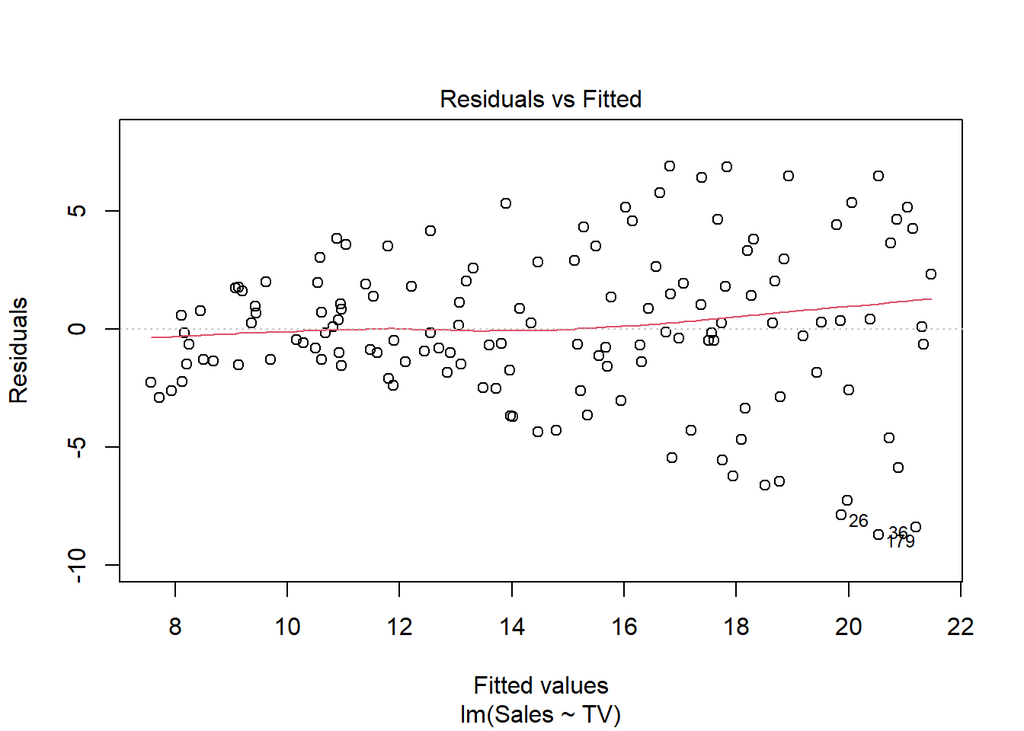

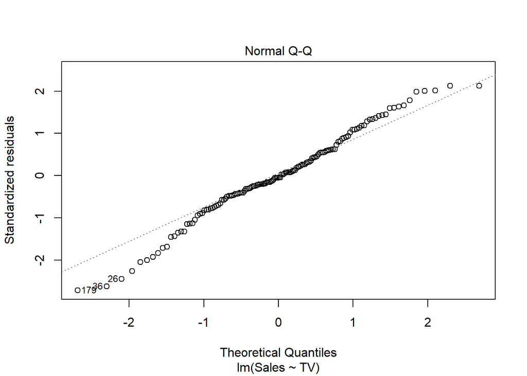

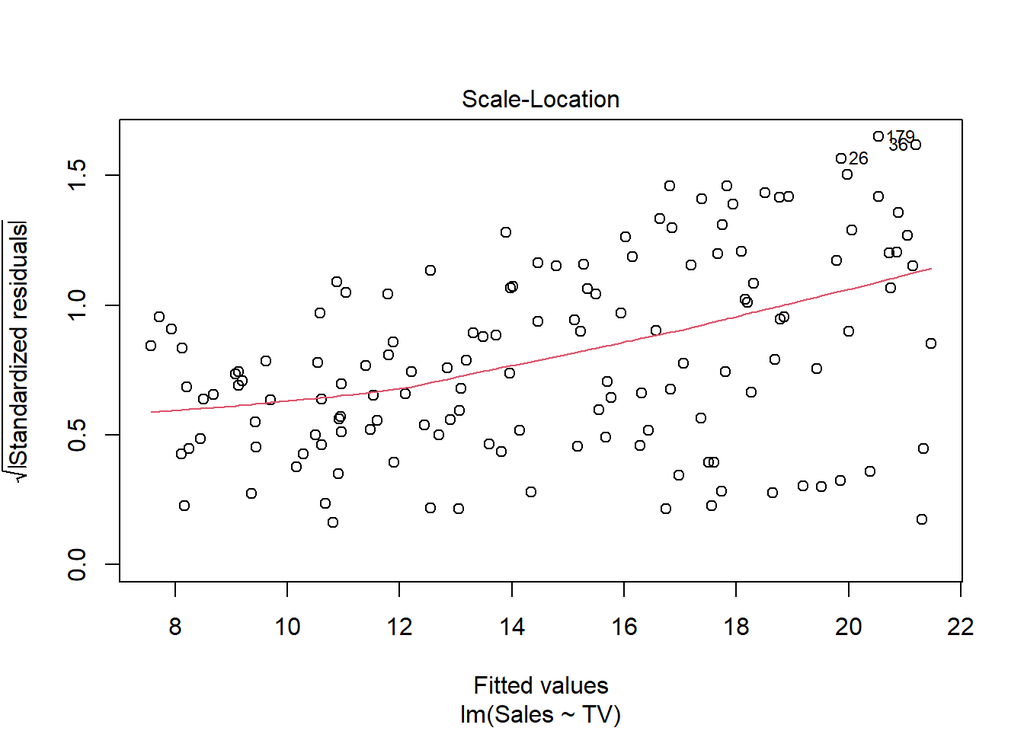

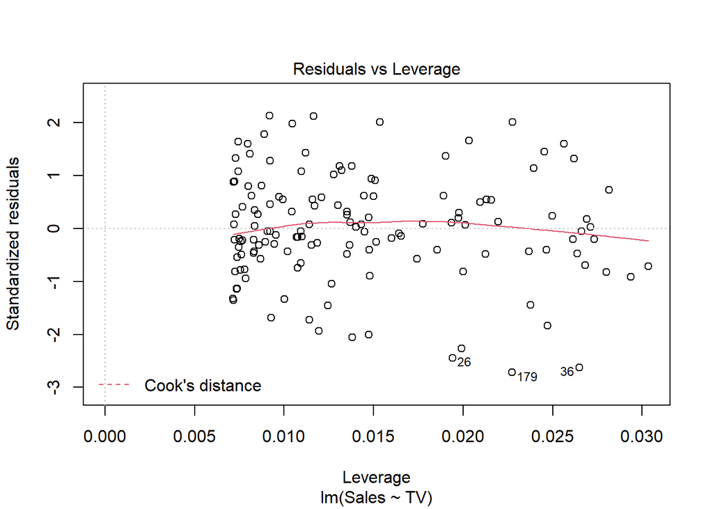

```r
# Residual plots
plot(m1)
```

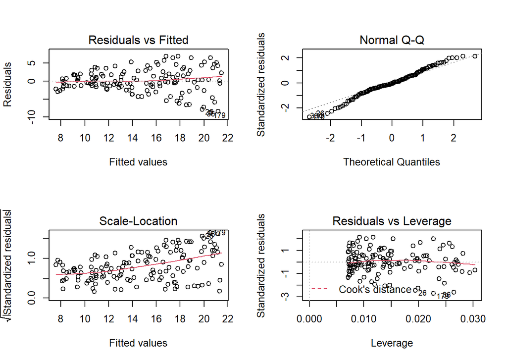

```r
# Four plots in one single page
par(mfrow=c(2,2))
plot(m1)
```

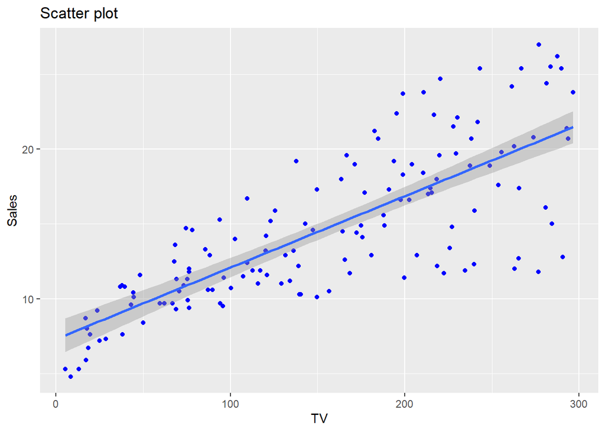

```r
par(mfrow=c(1,1)) #resetting plot space back

# Plotting Regression Line
# x= TV, y = Sales
# line = regression line
ggplot(tr) +
  geom_point(aes(x=TV, y=Sales), color="blue") +
  geom_smooth(aes(x=TV, y=Sales), method = "lm")+
  ggtitle("Scatter plot")
```

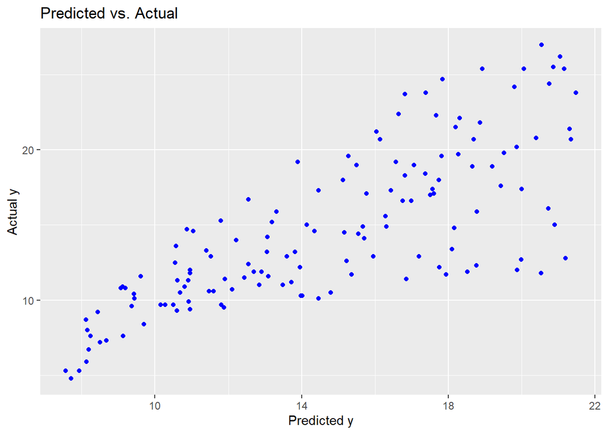

```r
# x1= fitted.value (yhat) y= Sales (actual)
ggplot(data=tr) +
  geom_point(aes(x= m1$fitted.values, y=Sales), color="blue") +
  labs(title="Predicted vs. Actual", x ="Predicted y", y = "Actual y")
```

# 4 Step 2. Making predictions

```r
# Apply m1 to validation data to generate prediction
# Point forecasts only
predict(m1, x_val) #R automatically reads TV variable only.
```

```
##         3         4         6         7        10        11        14        22
##  8.129047 14.546741  7.722864 10.054833 16.854817 10.465795 11.966283 18.651580
##        23        24        33        39        45        48        53        57
##  7.937902 18.216725 11.951948  9.366711  8.506559 18.771046 17.648069  7.655963
##        61        63        65        67        68        73        77        85
##  9.863688 18.742374 13.571902  8.812391 13.963749  8.587795  8.621246 17.509489
##        86        88        93        94        96        97        98       100
## 16.539428 12.597062 17.710191 19.296695 15.110619 16.749687 16.142802 13.767825
##       103       104       108       114       116       120       121       122
## 20.696832 16.286161 11.627001 17.323122 10.895871  8.234177 14.059321  8.205505
##       123       127       128       131       133       137       143       144
## 18.011244  7.679857 11.139581  7.340574  7.708528  8.530452 17.843993 12.305566
##       147       156       159       168       175       177       178       183
## 18.780603  7.503047  7.866223 17.189321 17.934786 19.177229 15.440344  9.992711
##       186       189       198       200
## 17.103306 20.973992 15.765291 18.398313
```

```r
# Predicting the average value for given x
# Confidence intervals: Estimates Average y values
head(predict(m1, x_val, interval = "confidence", level = 0.95))
```

```
##          fit       lwr       upr
## 3   8.129047  7.077477  9.180618
## 4  14.546741 14.003679 15.089804
## 6   7.722864  6.623160  8.822568
## 7  10.054833  9.218485 10.891182
## 10 16.854817 16.236131 17.473503
## 11 10.465795  9.671525 11.260065
```

```r
# Store point prediction to a vector
pred1 <- predict(m1, x_val)
```

# 5 Step 3. Evaluating the model performance

```r
# Computing algorithm performance
if(!"caret" %in% installed.packages()){install.packages("caret")}
library(caret)

# postResample (caret package): RMSE, R^2, MAE
postResample(pred1, y_val)
```

```
##      RMSE  Rsquared       MAE
## 3.3331356 0.6181277 2.7910934
```

```r
m1_result <- postResample(pred1, y_val)


# Put them in the data frame for later comparisons
result<- data.frame(m1 = round(m1_result,3))
result
```

```
##             m1
## RMSE     3.333
## Rsquared 0.618
## MAE      2.791
```

```r
#Want to compute MAPE (Mean Absolute Percentage Error)
if(!"Metrics" %in% installed.packages()){install.packages("Metrics")}
library(Metrics)
mape(y_val, pred1) #mape(actual y, prediction)
```

```
## [1] 0.2956927
```

# 6 Step 4: Iterate to Find Best Model

## 6.1 Full regression model

> Do the class exercise below - fill the code for the three Steps. Out goal is to get the `result` object for the full model.

```r
#Exercise
# Run the full Regression Model  (m2)
#  m2 <- lm(Sales ~ TV+ Radio + Newspaper, data = tr)
# Examine Regression Outputs
# Make predictions using validating data

#  Step 1. Running linear regression and evaluating the results

#  Step 2. Making predictions

#  Step 3. Evaluating the model performance
#          Put postResample result in the object, result
```

## 6.2 Smaller Regression Model

```r
# Model 3 (m3)  Sales ~ Tv+ Radio

#  Step 1. Running linear regression and evaluating the results

m3 <- lm(Sales ~ TV + Radio, data = tr)
summary(m3)
```

```
##
## Call:
## lm(formula = Sales ~ TV + Radio, data = tr)
##
## Residuals:
##     Min      1Q  Median      3Q     Max
## -4.2242 -0.6056  0.1956  0.9743  2.6474
##
## Coefficients:
##             Estimate Std. Error t value Pr(>|t|)
## (Intercept) 3.330013   0.301316   11.05   <2e-16 ***
## TV          0.042709   0.001459   29.27   <2e-16 ***
## Radio       0.199449   0.008201   24.32   <2e-16 ***
## ---
## Signif. codes:  0 '***' 0.001 '**' 0.01 '*' 0.05 '.' 0.1 ' ' 1
##
## Residual standard error: 1.414 on 137 degrees of freedom
## Multiple R-squared:  0.9249, Adjusted R-squared:  0.9238
## F-statistic: 843.3 on 2 and 137 DF,  p-value: < 2.2e-16
```

```r
#  Step 2. Making predictions

pred3 <- predict(m3, x_val)


#  Step 3. Evaluating the model performance
#          Put postResample result in the object, result

m3_result <- postResample(pred3, y_val)
result<- data.frame(result, m3 = round(m3_result,3))
result
```

```
##             m1    m3
## RMSE     3.333 2.280
## Rsquared 0.618 0.824
## MAE      2.791 1.605
```

## 6.3 Including dummy variable(s)

```r
#Including dummy variables
#Creating Train and Validation Set for data with dummy variable

#70-30 split
Ad_full <- read.csv("Advertising2.csv")
str(Ad_full)
```

```
## 'data.frame':    200 obs. of  5 variables:
##  $ TV       : num  230.1 44.5 17.2 151.5 180.8 ...
##  $ Radio    : num  37.8 39.3 45.9 41.3 10.8 48.9 32.8 19.6 2.1 2.6 ...
##  $ Newspaper: num  69.2 45.1 69.3 58.5 58.4 75 23.5 11.6 1 21.2 ...
##  $ Instagram: chr  "Yes" "No" "No" "No" ...
##  $ Sales    : num  22.1 10.4 9.3 18.5 12.9 7.2 11.8 13.2 4.8 10.6 ...
```

```r
#Train set
tr <- Ad_full[train_set, ]
x_tr <- Ad_full[train_set,-5]
y_tr <- Ad_full[train_set,5]

#Validation set
val <- Ad_full[-train_set, ]
x_val <- Ad_full[-train_set,-5]
y_val <- Ad_full[-train_set,5]

head(tr)
```

```
##        TV Radio Newspaper Instagram Sales
## 141  73.4  17.0      12.9        No  10.9
## 28  240.1  16.7      22.9        No  15.9
## 69  237.4  27.5      11.0       Yes  18.9
## 46  175.1  22.5      31.5        No  14.9
## 106 137.9  46.4      59.0       Yes  19.2
## 95  107.4  14.0      10.9        No  11.5
```

```r
#  Step 1. Running linear regression and evaluating the results

md1 <- lm(Sales~., tr)
summary(md1)
```

```
##
## Call:
## lm(formula = Sales ~ ., data = tr)
##
## Residuals:
##     Min      1Q  Median      3Q     Max
## -4.2362 -0.5852  0.1227  0.9722  2.6956
##
## Coefficients:
##               Estimate Std. Error t value Pr(>|t|)
## (Intercept)   3.362958   0.318886  10.546   <2e-16 ***
## TV            0.042317   0.001595  26.537   <2e-16 ***
## Radio         0.199915   0.008704  22.967   <2e-16 ***
## Newspaper    -0.003483   0.005561  -0.626    0.532
## InstagramYes  0.210237   0.270424   0.777    0.438
## ---
## Signif. codes:  0 '***' 0.001 '**' 0.01 '*' 0.05 '.' 0.1 ' ' 1
##
## Residual standard error: 1.418 on 135 degrees of freedom
## Multiple R-squared:  0.9255, Adjusted R-squared:  0.9232
## F-statistic:   419 on 4 and 135 DF,  p-value: < 2.2e-16
```

```r
#  Step 2. Making predictions

pred4 <- predict(md1, x_val)

#Creating predict interval
predict(md1, x_val, interval ="prediction", level= 0.95)
```

```
##           fit       lwr       upr
## 3   13.025562 10.124886 15.926237
## 4   17.826751 14.967107 20.686396
## 6   13.245760 10.327520 16.164000
## 7   12.271558  9.425563 15.117552
## 10  12.263863  9.404510 15.123215
## 11   7.235346  4.392249 10.078443
## 14   9.193390  6.339736 12.047045
## 22  14.557000 11.706390 17.407610
## 23   6.927455  4.066434  9.788476
## 24  16.311269 13.457406 19.165132
## 33   7.671575  4.823002 10.520149
## 39  10.402313  7.560670 13.243956
## 45   9.412134  6.562413 12.261854
## 48  21.957105 19.108944 24.805266
```

[output cut: 46 more lines]

```r
#  Step 3. Evaluating the model performance
#          Put postResample result in the object, result

# Evaluating model performance
postResample(pred4, y_val)
```

```
##      RMSE  Rsquared       MAE
## 2.2703320 0.8244933 1.5914760
```

```r
md1_result <- postResample(pred4, y_val)

result<- data.frame(result, md1 = round(md1_result,3))
result
```

```
##             m1    m3   md1
## RMSE     3.333 2.280 2.270
## Rsquared 0.618 0.824 0.824
## MAE      2.791 1.605 1.591
```

## 6.4 Interaction variables

```r
# Instagram*TV: Captures the interaction between Instagram and TV.

# InstagramYes =1,    InstagramYes*TV = 1*TV = TV
# InstagramNo (InstagramYes=0)    InstagramYes*TV = 0*TV = 0

md2 <- lm(Sales~ TV + Newspaper + Radio + Instagram + Instagram*TV, tr)
summary(md2)
```

```
##
## Call:
## lm(formula = Sales ~ TV + Newspaper + Radio + Instagram + Instagram *
##     TV, data = tr)
##
## Residuals:
##     Min      1Q  Median      3Q     Max
## -4.0085 -0.5440  0.1156  0.8897  2.7784
##
## Coefficients:
##                  Estimate Std. Error t value Pr(>|t|)
## (Intercept)      3.111748   0.366851   8.482 3.58e-14 ***
## TV               0.044525   0.002262  19.682  < 2e-16 ***
## Newspaper       -0.003499   0.005543  -0.631    0.529
## Radio            0.199879   0.008676  23.038  < 2e-16 ***
## InstagramYes     0.849110   0.538193   1.578    0.117
## TV:InstagramYes -0.004328   0.003156  -1.371    0.173
## ---
## Signif. codes:  0 '***' 0.001 '**' 0.01 '*' 0.05 '.' 0.1 ' ' 1
##
## Residual standard error: 1.414 on 134 degrees of freedom
## Multiple R-squared:  0.9265, Adjusted R-squared:  0.9237
## F-statistic: 337.8 on 5 and 134 DF,  p-value: < 2.2e-16
```

> Class Exercise - add model performace metrics for the `md2` model to the `result` object.

## 6.5 Polynomial regression

```r
# I(polynomial math expression)
md3 <- lm(Sales ~ TV + I(TV ^ 2)  +Instagram, data = tr)
summary(md3)
```

```
##
## Call:
## lm(formula = Sales ~ TV + I(TV^2) + Instagram, data = tr)
##
## Residuals:
##     Min      1Q  Median      3Q     Max
## -8.2223 -1.9153 -0.0612  1.9406  7.2086
##
## Coefficients:
##                Estimate Std. Error t value Pr(>|t|)
## (Intercept)   6.670e+00  9.211e-01   7.242 2.97e-11 ***
## TV            5.180e-02  1.444e-02   3.588 0.000464 ***
## I(TV^2)      -2.247e-05  4.469e-05  -0.503 0.615989
## InstagramYes  1.192e+00  6.201e-01   1.923 0.056625 .
## ---
## Signif. codes:  0 '***' 0.001 '**' 0.01 '*' 0.05 '.' 0.1 ' ' 1
##
## Residual standard error: 3.217 on 136 degrees of freedom
## Multiple R-squared:  0.6137, Adjusted R-squared:  0.6051
## F-statistic: 72.01 on 3 and 136 DF,  p-value: < 2.2e-16
```

> Class Exercise - add model performace metrics for the `md3` model to the `result` object.

# 7 Conclusion: Best Model

> Class Exercise - which is the best Linear Regression model among all that we studied today?